# Tests of different cluster methods and stepwise selection of SEM variables

Jingyao Sun

3/3/2022

## Load packages and data

```r
library("lavaan")
```

```r
library("magrittr")
library("pheatmap")
library("psych")
library("piecewiseSEM")
BSCdata <- read.csv("BSCdata.csv")
```

## Tests of different cluster methods

```r
BSCdata <- subset(BSCdata,select =
                    c("RMo","RLi","RCA",
                      "BM","TSW","cvPP",
                      "SOM","TN","TP","TK",
                      "silt","clay","pH","Ca","SS"))
fc <- subset(BSCdata, select = c("TSW","BM","cvPP",
                                "pH","SS","Ca","silt","clay",
                                "SOM","TN","TP","TK"))
sp <- subset(BSCdata, select =
               c("RCA","RLi","RMo"))
data_heat <- cor(sp$RCA, fc) %>%
  rbind(cor(sp$RLi, fc)) %>%
  rbind(cor(sp$RMo, fc))
row.names(data_heat) <- c("RCA","RLi","RMo")
colnames(data_heat) <- c("TSW","BM","cvPP","pH","SS","Ca","Silt",
                         "Clay","SOM","TN" ,"TP" ,"TK")
```

Plotting cluster results with different methods.

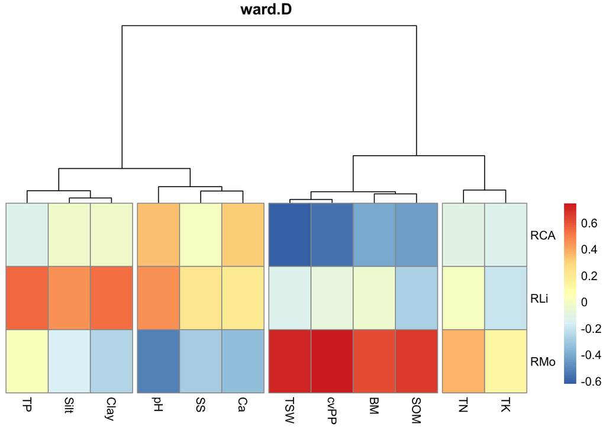

```r
pheatmap(data_heat, cluster_row = FALSE,
         fontsize_number = 20,
         cutree_col = 4,treeheight_col=150,
         clustering_method= "ward.D",main="ward.D")
```

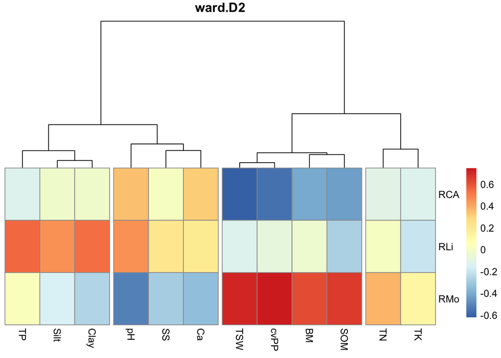

```r
pheatmap(data_heat, cluster_row = FALSE,
         fontsize_number = 20,
         cutree_col = 4,treeheight_col=150,
         clustering_method= "ward.D2",main="ward.D2")
```

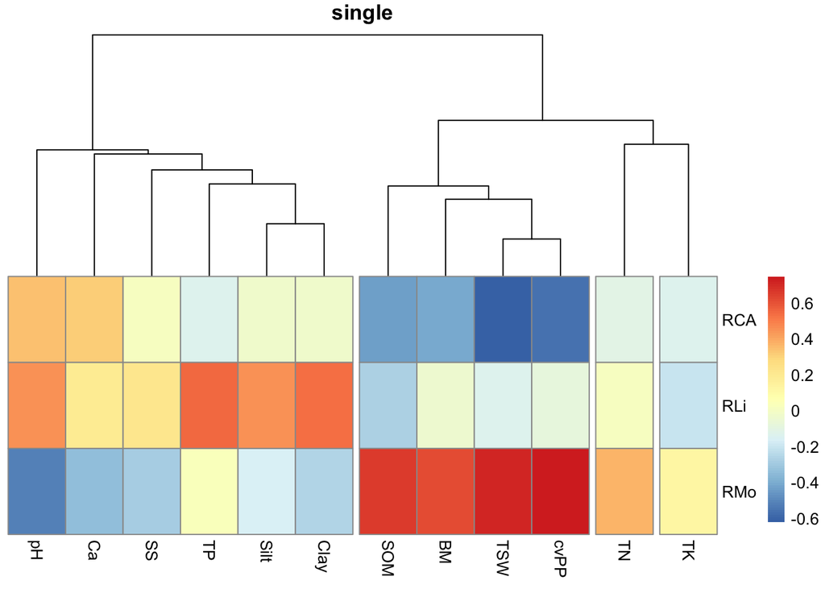

```r
pheatmap(data_heat, cluster_row = FALSE,
         cutree_col = 4,treeheight_col=150,
         clustering_method= "single",main="single")
```

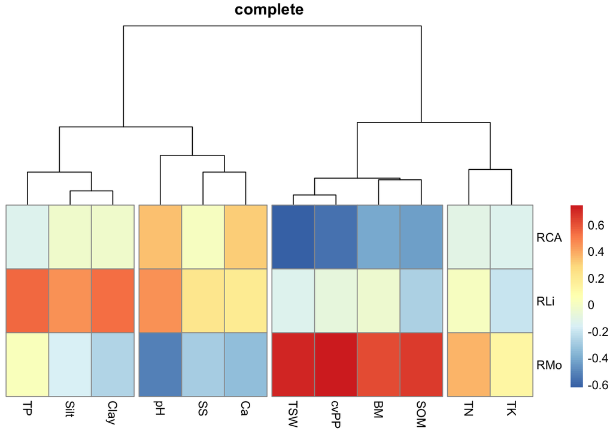

```r
pheatmap(data_heat, cluster_row = FALSE,
         cutree_col = 4,treeheight_col=150,
         clustering_method= "complete",main="complete")
```

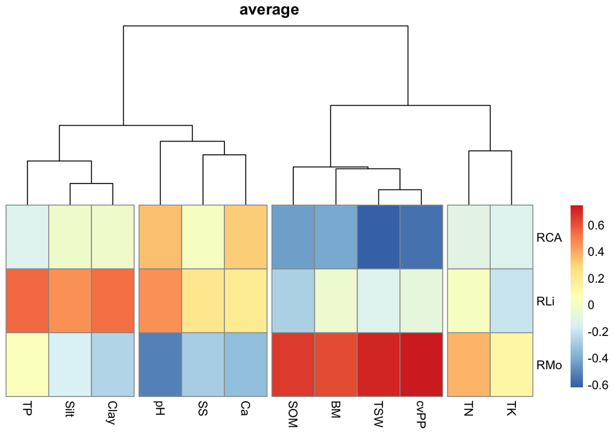

```r
pheatmap(data_heat, cluster_row = FALSE,
         cutree_col = 4,treeheight_col=150,
         clustering_method= "average",main="average")
```

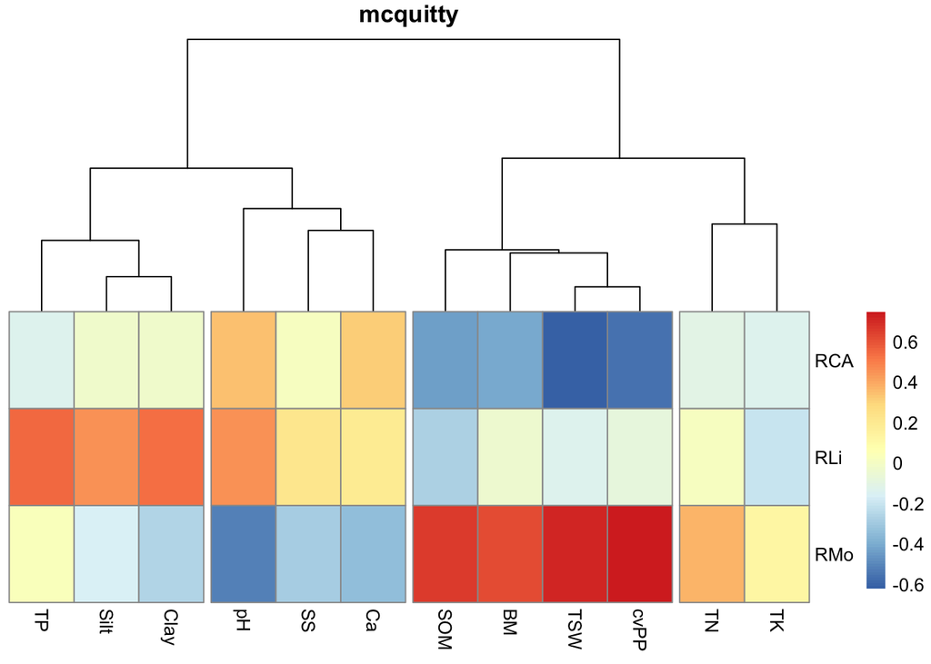

```r
pheatmap(data_heat, cluster_row = FALSE,
         cutree_col = 4,treeheight_col=150,
         clustering_method= "mcquitty",main="mcquitty")
```

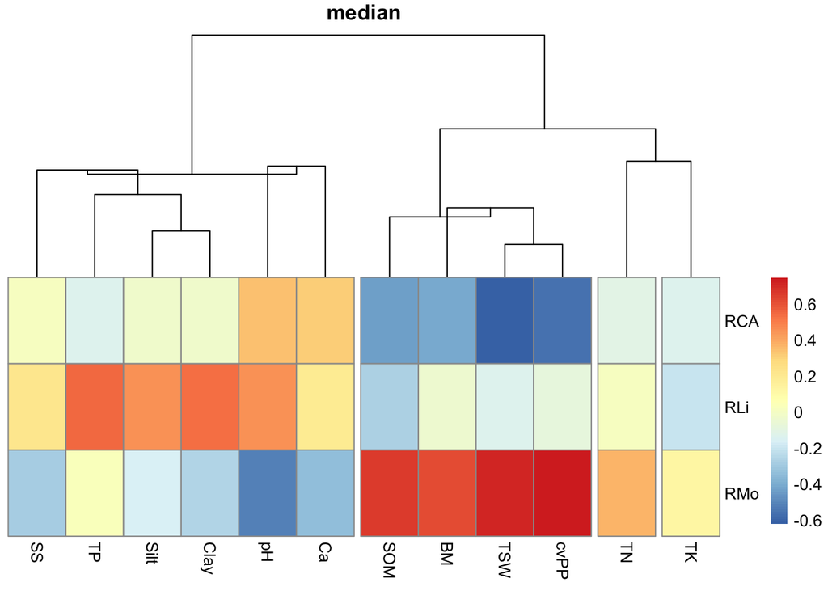

```r
pheatmap(data_heat, cluster_row = FALSE,
         cutree_col = 4,treeheight_col=150,
         clustering_method= "median",main="median")
```

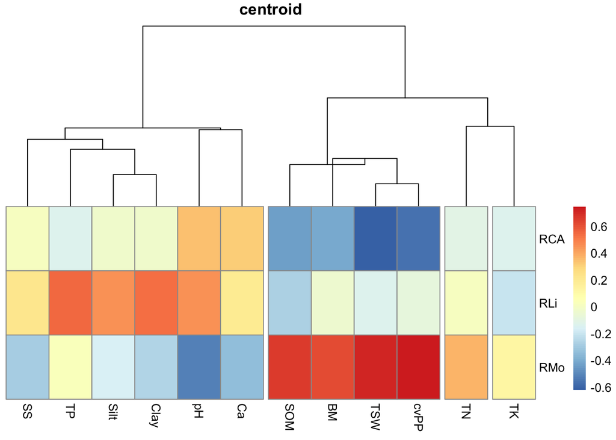

```r
pheatmap(data_heat, cluster_row = FALSE,
         cutree_col = 4,treeheight_col=150,
         clustering_method= "centroid",main="centroid")
```

Clustering results are basically the same, except for the “single”, “median” and “centroid” method. But the “median” and “centroid” methods show reversed tree.

## Tentative test of piecewiseSEM

As shown in cluster plot, many variables are clustered together. So, the ecological inference based on bi-variate correlations is unreliable. For example, the strong correlation between TP and RLi are highly likely from correlation between fine particle and RLi, or in opposite way. Therefor, factor analysis is key to find the latent or low-level cause behind the correlated variables. There is no latent variable in piecewise SEM, so we conduct the factor analysis separately.

```r
BSCdata$fa1 <- fa(subset(BSCdata, select = c("TSW","BM","cvPP","SOM"),nfactors = 1,score=T))$scores
BSCdata$fa2 <- fa(subset(BSCdata, select = c("clay","silt","TP"),nfactors = 1,score=T))$scores
BSCdata$fa3 <- fa(subset(BSCdata, select = c("pH","Ca","SS"),nfactors = 1,score=T))$scores
pwm <- psem(
  lm(RMo ~ fa1 + fa2 + fa3 ,data=BSCdata),
  lm(RLi ~ fa1 + fa2 + fa3 ,data=BSCdata),
  lm(RCA ~ fa1 + fa2 + fa3 ,data=BSCdata)
)
summary(pwm)
```

[output not shown]

The overall estimation fails with “Fisher’s C = 107.031 with P-value = 0 and on 6 degrees of freedom”, because indirect path is lacking. Apparently, a nested model with from continentality or longitude or region to clustered environmental factors to diversity pattern is promising for piecewiseSEM. However, the ecological topic in new model is beyond the scope of this article. limited by time, we plan to study the piecewiseSEM in the future.

## Stepwise model adjustment

```r
subdata <- subset(BSCdata,select =
                    c("RMo","RLi","RCA",
                      "BM","TSW","cvPP",
                      "SOM","TN","TP","TK",
                      "silt","clay","pH","Ca","SS")) %>%
  scale()%>% as.data.frame()
model0 <- '
group1 =~  TSW  + cvPP  + SOM  + BM
group2 =~  clay + silt  + TP
group3 =~  pH   + Ca    + SS
RMo ~ group1 + group2 + group3
RLi ~ group1 + group2 + group3
RCA ~ group1 + group2 + group3
'
fit0  <- sem(model0,data=subdata)
fitmeasures(fit0,fit.measures = c("chisq","df","pvalue","rmsea","tli","cfi"))
```

```
##   chisq      df  pvalue   rmsea     tli     cfi
## 351.733  54.000   0.000   0.140   0.888   0.923
```

```r
summary(fit0,standard=T)
```

[output not shown]

[output cut: 27 more lines]

```
##    .cvPP              0.416    0.032   13.196    0.000    0.416    0.416
##    .SOM               0.439    0.042   10.381    0.000    0.439    0.439
##    .BM                0.668    0.175    3.815    0.000    0.668    0.668
##    .clay              0.262    0.099    2.644    0.008    0.262    0.262
##    .silt              0.447    0.053    8.450    0.000    0.447    0.447
##    .TP                0.615    0.057   10.858    0.000    0.615    0.615
##    .pH                0.049    0.054    0.906    0.365    0.049    0.049
##    .Ca                0.726    0.116    6.284    0.000    0.726    0.726
##    .SS                0.607    0.049   12.475    0.000    0.607    0.607
##    .RMo               0.053    0.028    1.899    0.058    0.053    0.053
##    .RLi               0.634    0.052   12.103    0.000    0.634    0.634
##    .RCA               0.473    0.053    8.897    0.000    0.473    0.473
##     group1            0.576    0.058    9.986    0.000    1.000    1.000
##     group2            1.262    0.129    9.771    0.000    1.000    1.000
##     group3            0.951    0.084   11.353    0.000    1.000    1.000
```

```r
model1 <- '
group1 =~  TSW  + cvPP + SOM
group2 =~  clay + silt
group3 =~  pH   + Ca
RMo ~ group1 + group2 + group3
RLi ~ group1 + group2 + group3
RCA ~ group1 + group2 + group3
'
fit1  <- sem(model1,data=subdata)
fitmeasures(fit1,fit.measures = c("chisq","df","pvalue","rmsea","tli","cfi"))
```

```
##  chisq     df pvalue  rmsea    tli    cfi
## 99.822 24.000  0.000  0.106  0.949  0.973
```

```r
summary(fit1,standard=T)
```

[output not shown]

[output cut: 21 more lines]

```
## Variances:
##                    Estimate  Std.Err  z-value  P(>|z|)   Std.lv  Std.all
##    .TSW               0.471    0.033   14.466    0.000    0.471    0.471
##    .cvPP              0.498    0.035   14.194    0.000    0.498    0.498
##    .SOM               0.426    0.046    9.240    0.000    0.426    0.426
##    .clay              0.169    0.127    1.332    0.183    0.169    0.169
##    .silt              0.503    0.065    7.674    0.000    0.503    0.503
##    .pH                0.018    0.058    0.319    0.749    0.018    0.018
##    .Ca                0.651    0.105    6.216    0.000    0.651    0.651
##    .RMo               0.008    0.046    0.169    0.866    0.008    0.008
##    .RLi               0.670    0.056   11.954    0.000    0.670    0.670
##    .RCA               0.417    0.062    6.694    0.000    0.417    0.417
##     group1            0.529    0.055    9.644    0.000    1.000    1.000
##     group2            1.169    0.157    7.439    0.000    1.000    1.000
##     group3            1.018    0.089   11.402    0.000    1.000    1.000
```

Delete SOM

```r
model2 <- '
group1 =~  TSW  + cvPP
group2 =~  clay + silt
group3 =~  pH   + Ca
RMo ~ group1 + group2 + group3
RLi ~ group1 + group2 + group3
RCA ~ group1 + group2 + group3
'
fit2  <- sem(model2,data=subdata)
fitmeasures(fit2,fit.measures = c("chisq","df","pvalue","rmsea","tli","cfi"))
```

[output not shown]

```r
summary(fit2,standard=T)
```

[output not shown]

[output cut: 19 more lines]

[output not shown]

Delete the insignificant path in structure model. However, Your comment remind us the deletion of insignificant path may improve the model fit. However, the variable adjustment is lengthy, we decided to move it to appendix.

```r
model3 <- '
group1 =~  TSW  + cvPP
group2 =~  clay + silt
group3 =~  pH   + Ca
RMo ~ group1 + group2 + group3
RLi ~ group2
RCA ~ group1
'
fit3  <- sem(model3,data=subdata,
             estimator="WLSM")
fitmeasures(fit3,fit.measures = c("chisq","df","pvalue","rmsea","tli","cfi"))
```

[output not shown]

```r
summary(fit3,standard=T)
```

[output not shown]

[output cut: 15 more lines]

```
##
## Variances:
##                    Estimate  Std.Err  z-value  P(>|z|)   Std.lv  Std.all
##    .TSW               0.191    0.041    4.656    0.000    0.191    0.191
##    .cvPP              0.266    0.039    6.829    0.000    0.266    0.266
##    .clay              0.004    0.099    0.040    0.982    0.004    0.004
##    .silt              0.414    0.057    7.262    0.000    0.414    0.414
##    .pH                0.084    0.067    1.251    0.211    0.084    0.084
##    .Ca                0.442    0.111    3.982    0.000    0.442    0.442
##    .RMo               0.077    0.043    1.808    0.071    0.077    0.077
##    .RLi               0.585    0.062    9.503    0.000    0.585    0.585
##    .RCA               0.458    0.065    7.042    0.000    0.458    0.458
##     group1            0.669    0.063   10.687    0.000    1.000    1.000
##     group2            1.002    0.136    7.356    0.000    1.000    1.000
##     group3            1.084    0.098   11.070    0.000    1.000    1.000
```